# ST558-651 Homework 10

James Carr

7/5/2021

```r
#read data/clean it
titanicData <- read_csv("titanic.csv")
titanicData <- filter(titanicData, !is.na(survived) & !is.na(fare) & !is.na(age))  %>% select(survived, age, fare)
titanicData$survived <- as.factor(titanicData$survived)
set.seed(1)
train <- sample(1:nrow(titanicData), size = nrow(titanicData)*0.8)
test <- dplyr::setdiff(1:nrow(titanicData), train)
titanicDataTrain <- titanicData[train, ]
titanicDataTest <- titanicData[test, ]
```

We filtered our data to remove NAs on the relevant columns so there is no need to check for null values. Looking at the summaries of each column, nearly 60% of passengers in the training set did not survive, and age and fair are on different scales and should be standardized. Everything should be all set to begin using crossvalidation on our KNN model.

```r
summary(titanicDataTrain)
```

```
##  survived      age               fare
##  0:490    Min.   : 0.1667   Min.   :  0.00
##  1:346    1st Qu.:21.0000   1st Qu.:  8.05
##           Median :28.0000   Median : 15.02
##           Mean   :29.3458   Mean   : 35.24
##           3rd Qu.:37.0000   3rd Qu.: 32.50
##           Max.   :80.0000   Max.   :512.33
```

In the `trctrl` variable we have the method set to ‘repeatedcv’, the number of folds to set to 10, and number of repeats is set to 3. If it was set to 1, it would just be the same as the normal cv method.

```r
trctrl <- trainControl(method='repeatedcv', number=10, repeats=3)
set.seed(1)
knn_fit <- train(survived ~ ., data=titanicDataTrain, method='knn',
                 trControl = trctrl,
                 preProcess = c('center', 'scale'),
                 tuneGrid = data.frame(k=2:30))

best_fit <- unlist(knn_fit$bestTune)
knn_fit
```

```
## k-Nearest Neighbors
##
## 836 samples
##   2 predictor
##   2 classes: '0', '1'
##
## Pre-processing: centered (2), scaled (2)
## Resampling: Cross-Validated (10 fold, repeated 3 times)
## Summary of sample sizes: 752, 753, 752, 752, 752, 753, ...
## Resampling results across tuning parameters:
##
##   k   Accuracy   Kappa
##    2  0.5881383  0.1465465
##    3  0.6152610  0.1960537
##    4  0.6228581  0.2071347
```

[output cut: 29 more lines]

Using accuracy, the k = 21 model provided the best fit. Graphing accuracy based on k-nearest neighbors we get:

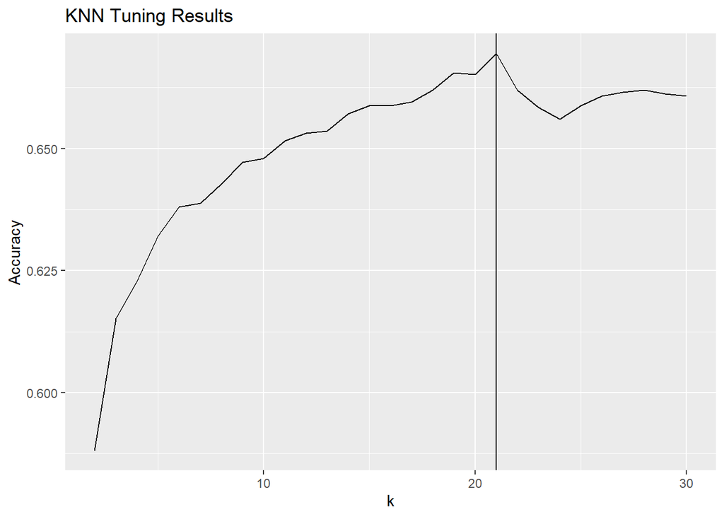

```r
ggplot(data=knn_fit$results, aes(x=k, y=Accuracy)) +
         geom_line() +
         ggtitle('KNN Tuning Results') +
         geom_vline(xintercept=best_fit)
```

Looking at how this model does with prediction, we were able to correctly classify 70% of the time, which is better than simply guessing everyone died which occurred at a 60% rate.

```r
pred <- predict(knn_fit, newdata=titanicDataTest)
confusionMatrix(pred, titanicDataTest$survived)
```

```
## Confusion Matrix and Statistics
##
##           Reference
## Prediction   0   1
##          0 105  37
##          1  23  44
##
##                Accuracy : 0.7129
##                  95% CI : (0.6465, 0.7732)
##     No Information Rate : 0.6124
##     P-Value [Acc > NIR] : 0.001529
##
##                   Kappa : 0.3754
##
##  Mcnemar's Test P-Value : 0.093290
##
##             Sensitivity : 0.8203
##             Specificity : 0.5432
##          Pos Pred Value : 0.7394
##          Neg Pred Value : 0.6567
##              Prevalence : 0.6124
##          Detection Rate : 0.5024
##    Detection Prevalence : 0.6794
##       Balanced Accuracy : 0.6818
##
##        'Positive' Class : 0
##
```